# Assignment 0 (Basics)

Lacey Goodstudent - ID: 123456

This document is for demonstration purposes only. Comments are written in *italics* and should not be included in your homework files.

## Assignment

*This section is provided to you*

The data was extracted from the 1974 Motor Trend US magazine, and comprises fuel consumption and 10 aspects of automobile design and performance for 32 automobiles (1973-74 models).

The following variables are included in the dataset:

- mpg: Miles/(US) gallon
- cyl: Number of cylinders
- disp: Displacement (cu.in.)
- hp: Gross horsepower
- drat: Rear axle ratio
- wt: Weight (1000 lbs)
- qsec: 1/4 mile time
- vs: V/S
- am: Transmission (0 = automatic, 1 = manual)
- gear: Number of forward gears
- carb: Number of carburetors

Use R and appropriate analytical techniques to answer the following questions:

## Data Analysis

*This section needs to be edited by you*

### Load the data

```r
carData <- read.table("https://gist.githubusercontent.com/seankross/a412dfbd88b3db70b74b/raw/5f23f993cd87c283ce766e7ac6b329ee7cc2e1d1/mtcars.csv",
                      sep = ',', # make sure to use the appropriate separator!
                      stringsAsFactors = FALSE, # Do not convert string variables to factors
                      header = TRUE) # First line includes variable names
# Make sure this worked:
head(carData)
```

```
##               model  mpg cyl disp  hp drat    wt  qsec vs am gear carb
## 1         Mazda RX4 21.0   6  160 110 3.90 2.620 16.46  0  1    4    4
## 2     Mazda RX4 Wag 21.0   6  160 110 3.90 2.875 17.02  0  1    4    4
## 3        Datsun 710 22.8   4  108  93 3.85 2.320 18.61  1  1    4    1
## 4    Hornet 4 Drive 21.4   6  258 110 3.08 3.215 19.44  1  0    3    1
## 5 Hornet Sportabout 18.7   8  360 175 3.15 3.440 17.02  0  0    3    2
## 6           Valiant 18.1   6  225 105 2.76 3.460 20.22  1  0    3    1
```

### Load the necessary libraries

*You can include options for single chunks in ````{r, options...}` at the beginning of each chunk. When loading the libraries it is good to set `{r, warning=FALSE, message=FALSE}` to avoid printing long messages.*

With ````{r, warning=FALSE, message=FALSE}`:

```r
library(ggplot2)
library(dplyr)
```

With ````{r}`:

```r
library(ggplot2)
library(dplyr)
```

### Question 1

*Description of the steps before the code*

Firs we want to analyze the effect of weight on fuel efficiency…

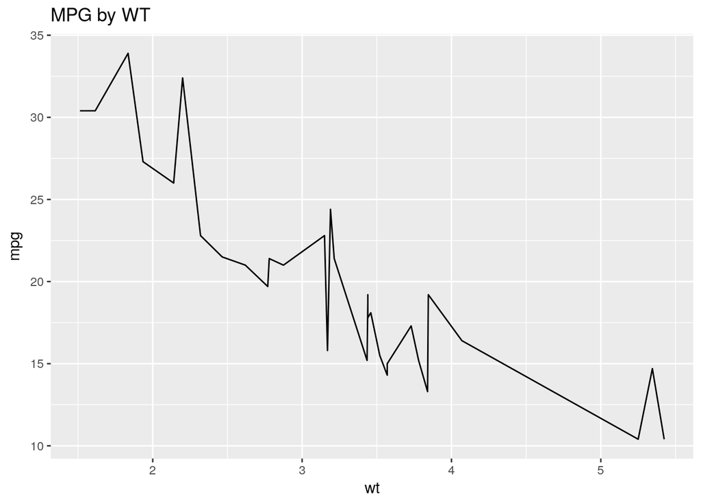

```r
ggplot(carData, aes(x = wt, y = mpg)) +
  geom_line() +
  ggtitle("MPG by WT")
```

```r
reg <- lm(mpg~wt, data = carData)
summary(reg)
```

```
##
## Call:
## lm(formula = mpg ~ wt, data = carData)
##
## Residuals:
##     Min      1Q  Median      3Q     Max
## -4.5432 -2.3647 -0.1252  1.4096  6.8727
##
## Coefficients:
##             Estimate Std. Error t value Pr(>|t|)
## (Intercept)  37.2851     1.8776  19.858  < 2e-16 ***
## wt           -5.3445     0.5591  -9.559 1.29e-10 ***
## ---
## Signif. codes:  0 '***' 0.001 '**' 0.01 '*' 0.05 '.' 0.1 ' ' 1
##
## Residual standard error: 3.046 on 30 degrees of freedom
## Multiple R-squared:  0.7528, Adjusted R-squared:  0.7446
## F-statistic: 91.38 on 1 and 30 DF,  p-value: 1.294e-10
```

*Interpretation of results after the code*

An additional 1000 pounds significantly decrease the miles per gallon by 5.35, on average. …

### Question 2

*You may separate your code into multiple chunks per question if you prefere doing so*

#### 2.1

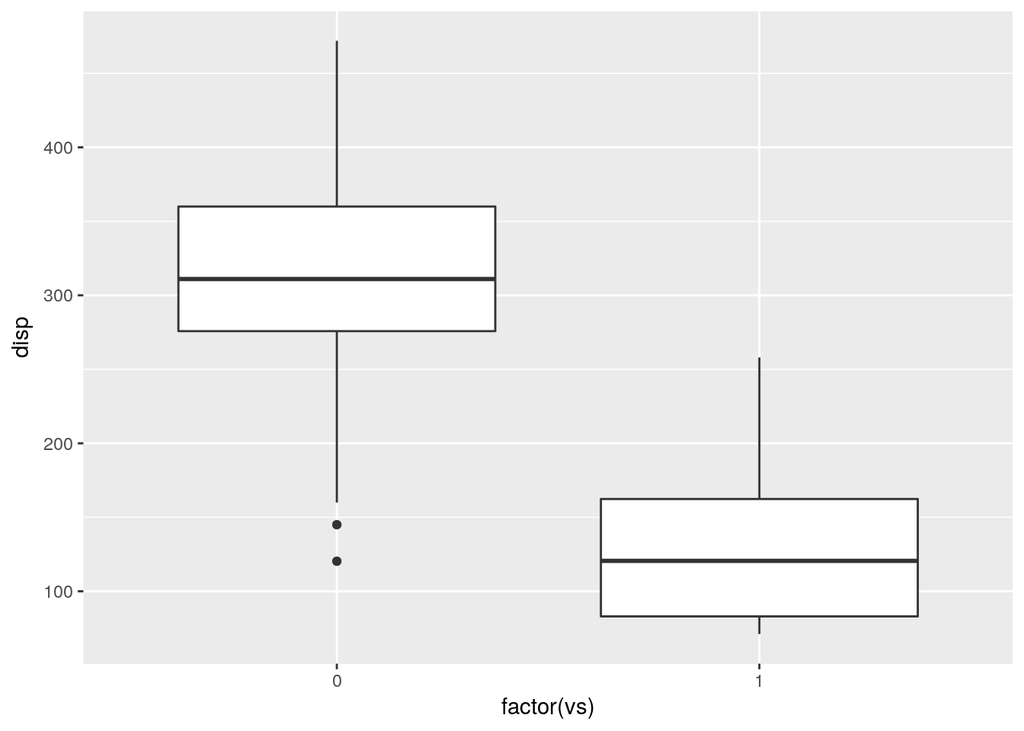

```r
ggplot(carData, aes(y = disp, x = factor(vs), group = vs)) +
  geom_boxplot()
```

#### 2.2

```r
t.test(disp~vs, data = carData)
```

```
##
##  Welch Two Sample t-test
##
## data:  disp by vs
## t = 5.9416, df = 26.977, p-value = 2.477e-06
## alternative hypothesis: true difference in means is not equal to 0
## 95 percent confidence interval:
##  114.3628 235.0229
## sample estimates:
## mean in group 0 mean in group 1
##        307.1500        132.4571
```